# Module 1: Introduction to Python and Its Business Applications

Author

Affiliation

Dr. Smith

University of South Florida

# Introduction

Welcome to Module 1! Think of this module as the very first step on an exciting journey into the world of programming, specifically tailored for business applications. We’ll be learning **Python**, which is like learning a new language, but instead of talking to people, you’re learning how to give instructions to a computer.

Why Python? It’s become incredibly popular in the business world because it’s powerful yet relatively easy to learn compared to many other programming languages. Businesses use it for all sorts of things: analyzing sales data to find trends, automating repetitive tasks like generating reports, creating visualizations like charts and graphs, and even building custom software tools.

Imagine you have a huge spreadsheet of customer data. Python can help you sift through it, clean it up, find your most valuable customers, and even predict future sales – tasks that might be incredibly time-consuming or even impossible by hand or with simpler tools.

This module is designed with the absolute beginner in mind. We’ll assume you have no prior programming experience. Every new term and concept will be explained clearly. Our goal is to build your confidence and give you a solid foundation. By the end of this module, you’ll understand *why* Python is useful in business, you’ll have your own programming toolkit set up (using a program called **Thonny**), and you’ll have written and run your very first simple Python program! Let’s get started.

**The Origin of Python’s Name**

Despite what many assume, Python programming language was not named after the snake! The creator of Python, Guido van Rossum, was actually a big fan of the British comedy group Monty Python. He chose the name as a tribute to “Monty Python’s Flying Circus,” the troupe’s iconic sketch comedy show that aired from 1969 to 1974.

Van Rossum wanted a name that was short, unique, and slightly mysterious—and being a fan of their absurdist humor, “Python” seemed perfect. This connection to comedy rather than reptiles explains why Python documentation often contains references to Monty Python sketches and jokes.

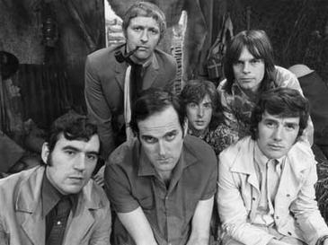

The language’s playful origin reflects its philosophy of being fun to use, which contributed to its growing popularity among programmers of all levels.

# Learning Outcomes

By the end of Module 1, you will be able to:

- **Explain the Importance of Python:** Understand *why* Python was created, how it has grown, and its significant role in modern business. You’ll be able to articulate its advantages for tasks like data analysis, automating routine work, and connecting different software systems.
- **Set Up the Python Environment:** Successfully install **Thonny**, the specific software (called an Integrated Development Environment or IDE) we’ll use in this course to write and run Python code.
- **Navigate Thonny:** Become comfortable with the main parts of the Thonny window – where you type your instructions (the editor), where you see the results (the shell), and how to use basic tools like the debugger.
- **Write and Run Basic Python Programs:** Create a simple set of instructions (a script) in Python, save it as a file, and make the computer execute those instructions.
- **Understand Fundamental Python Concepts:** Grasp the basic building blocks of Python programming:
  - **Variables:** How to store information (like numbers or text) using names.
  - **Data Types:** Recognizing different kinds of information (like whole numbers, decimal numbers, and text).
  - **Comments:** How to leave notes within your code for yourself and others.
  - **Basic Arithmetic:** Performing simple calculations like addition, subtraction, multiplication, and division using Python. We’ll use business-related examples to make it practical.
- **Utilize Debugging Tools:** Learn how to use Thonny’s built-in ‘debugger’ to step through your code line-by-line, helping you understand exactly what the computer is doing and find any mistakes (bugs).

# 1. Why Python for Business?

So, why are we focusing on Python out of all the programming languages out there? Let’s explore its origins and why it’s become such a powerhouse in the business world.

## 1.1 The Evolution of Python

Python wasn’t born yesterday! It was created back in the late 1980s by a programmer named Guido van Rossum. His main goal was to create a language that was easy to read and write. Think of it like designing a language with clear grammar and simple sentence structures. This focus on **readability** and **simplicity** is a key reason for Python’s success.

Initially, Python was often used for smaller tasks, sometimes called “scripting” – writing short programs to automate simple jobs. But over time, it grew significantly. A huge community of developers started building tools and extensions (called **libraries** or **packages**) for Python, making it capable of handling very complex tasks.

Today, Python is a versatile and robust language used across countless industries. For business, its strengths lie in:

- **Data Analysis:** Python, with libraries like **Pandas**, is exceptional at taking raw data (like sales figures, customer surveys, website traffic), cleaning it up, transforming it, and performing sophisticated analysis to uncover insights. Imagine automatically processing thousands of transaction records to identify purchasing patterns.
- **Automation:** Many business processes involve repetitive, time-consuming tasks (e.g., generating weekly sales reports, sending reminder emails, downloading files). Python can automate these tasks, freeing up employees for more strategic work and reducing errors.
- **Visualization:** Understanding data often requires seeing it visually. Libraries like **Matplotlib** and **Seaborn** allow you to create all sorts of charts and graphs (line charts, bar graphs, heat maps) directly from your data, making complex information easier to understand and present.
- **Integration:** Businesses rarely use just one piece of software. Python acts like a universal adapter, making it easier to connect different systems – like pulling data from a company database, getting information from a website’s API (Application Programming Interface), and feeding results into a reporting tool.

## 1.2 Python’s Role in Modern Business

In today’s world, data is everywhere. Businesses that can effectively collect, analyze, and act on data have a significant competitive advantage. Python is a key enabler in this data-driven environment:

- **Empowering Decision-Making:** Instead of relying on gut feelings, businesses can use Python to analyze vast amounts of data, identify trends, test hypotheses, and make more informed, evidence-based decisions. (e.g., Which marketing campaign generated the most leads? Which products are most profitable?)
- **Enhancing Efficiency:** Automating tasks with Python doesn’t just save time; it increases accuracy (computers don’t make typos!) and allows processes to run 24/7 if needed. This boosts overall productivity.
- **Facilitating Integration:** Python helps break down data silos. It can connect your customer relationship management (CRM) system to your sales database, or pull data from online sources into your internal analytics platform, creating a more unified view of the business.
- **Enabling Custom Solutions:** Sometimes, off-the-shelf software doesn’t quite meet a specific business need. Python’s flexibility allows companies to build custom tools and applications perfectly tailored to their unique processes or challenges.

## 1.3 Python vs. Traditional Business Tools

You might be thinking, “I already use Excel, isn’t that enough?” Or maybe you’ve heard of SQL or specialized tools like Tableau. Where does Python fit in? It’s helpful to compare:

[output not shown]

**Business Insight:** Think of these tools as a team, each playing a specific role. Python is often the versatile star player that connects the others and handles the heavy lifting behind the scenes. A common workflow might look like this:

1. **SQL:** Extract raw sales data from the company database.
2. **Python:** Load the data, clean up errors (like missing values or typos), calculate new metrics (like profit margin per transaction), maybe even build a simple forecast model.
3. **Python/BI Tool:** Create charts visualizing sales trends or model predictions.
4. **Excel/BI Tool:** Present a summary report or interactive dashboard to management.

Python acts as the powerful engine in the middle, transforming raw data into valuable insights.

# 2. Setting Up Your Python Environment with Thonny

Okay, enough talk about *why* Python is great. Let’s get our hands dirty! To start writing and running Python code, we need a special kind of software called an **Integrated Development Environment** (IDE).

Think of an IDE like a specialized workshop for a craftsperson. Instead of wood and tools, you have code and programming utilities. An IDE bundles together several useful tools:

- A **Text Editor:** Specifically designed for writing code, often with features like syntax highlighting (coloring different parts of the code to make it easier to read) and auto-completion.
- An **Interpreter/Compiler:** The part that translates your human-readable code into instructions the computer can actually understand and execute.
- A **Debugger:** A tool to help you find and fix errors (called “bugs”) in your code.

For this course, we’ll use **Thonny**.

## 2.1 What is Thonny?

Thonny is an IDE specifically designed for beginners learning Python. It’s simple, clean, and has everything we need without overwhelming you with too many complex features found in professional IDEs. It comes with Python built-in, so you don’t need a separate installation.

Key features we’ll use:

- **Editor:** The main, large area at the top where you’ll type your Python instructions (your code).
- **Shell:** The panel at the bottom. This is where you’ll see the output of your programs (like messages or results of calculations) and where you can type single Python commands for quick testing. Think of it as a direct chat window with Python.
- **Debugger:** Tools (accessible via buttons or menus) that let you run your code step-by-step, watching what happens at each stage. This is incredibly useful for understanding how your code works and finding mistakes.
- **Variable Inspector:** A special window (you can open it from the ‘View’ menu) that shows you the values stored in your variables as your program runs. It’s like having X-ray vision into your code’s memory.

## 2.2 Installing Thonny

Getting Thonny installed is straightforward:

1. **Download Thonny:**
   - Open your web browser and go to the official Thonny website: thonny.org
   - You’ll see download links prominently displayed. Click the link that matches your computer’s operating system (Windows, macOS, or Linux).
2. **Installation Process:**
   - **Windows:** Find the downloaded `.exe` file (usually in your Downloads folder) and double-click it. An installation wizard will pop up. Just follow the on-screen instructions, accepting the default settings is usually fine.
   - **macOS:** Find the downloaded `.pkg` file and double-click it. Drag the Thonny icon to your Applications folder if prompted, or follow the installer steps. You might need to confirm that you trust the application developer.
   - **Linux:** The website usually provides specific instructions for different Linux distributions (like Ubuntu, Fedora). Often it involves running a command in your terminal. Follow the instructions provided on the site.
3. **First Launch:**
   - Once installed, find Thonny in your applications list (on Windows, check the Start Menu; on macOS, check the Applications folder) and open it.
   - Take a moment to look at the interface. You should see the Editor panel at the top and the Shell panel at the bottom. Don’t worry if it looks a bit empty now; we’ll fill it up soon!

## 2.3 Navigating the Thonny Interface

Let’s quickly recap the main parts of the Thonny window you’ll interact with most:

- **Editor (Top Panel):** This is your primary workspace for writing longer pieces of code (called scripts or programs). You’ll type your instructions here.
- **Shell (Bottom Panel):** This is where Python talks back to you. When you run your code from the editor, any output (like text printed to the screen or error messages) will appear here. You can also type Python commands directly into the shell (after the `>>>` prompt) and press Enter to see immediate results – great for quick tests.
- **Menu Bar (Top):** Standard menus like `File` (New, Open, Save), `Edit` (Cut, Copy, Paste), `View` (to show/hide panels like the Variable Inspector), and `Run` (to execute your code).
- **Toolbar (Below Menu Bar):** Contains shortcut buttons for common actions, most importantly the **Run** button (looks like a green play symbol ▶) and the **Debug** button (looks like a green bug 🐞).

**Thonny Interface Layout**

Here’s a quick visual guide to the main parts of Thonny:

```
┌───────────────────────────────────────────────────────────┐
│ File  Edit  View  Run  Tools  Help                        │ ← Menu Bar
├───────────────────────────────────────────────────────────┤
│ ▶ 🐞 ■                                                   │ ← Toolbar
├───────────────────────────────────────────────────────────┤
│                                                           │
│                                                           │
│                  EDITOR AREA                              │ ← Editor Panel
│ (Write multi-line programs here)                          │   (Write code here)
│                                                           │
│                                                           │
├───────────────────────────────────────────────────────────┤
│ >>> print("Hello, World!")                                │
│ Hello, World!                                             │ ← Shell Panel
│ >>>                                                       │   (See output here)
└───────────────────────────────────────────────────────────┘
```

# 3. Writing Your First Python Program

Alright, theory time is over! Let’s write some actual Python code. Our first program will be simple: it will display a friendly welcome message and calculate the total revenue from different business regions.

## 3.1 Step-by-Step Guide

Follow these steps carefully in Thonny:

### Step 1: Create a New File

- Make sure Thonny is open.
- Go to the menu bar and click **File > New**. This will open a blank, untitled tab in the Editor panel.

### Step 2: Write the Program Code

- Click inside the blank Editor panel.
- You can copy and paste the code below into Thonny, but be sure to check for any formatting issues that may occur when pasting.

```python
# My First Business Python Program
# This line is a comment - Python ignores it. It's just a note for humans.

# Use the print() function to display a message in the Shell
print("Welcome to Business Python!")

# Let's imagine we have revenue data from four different sales regions.
# We use 'variables' to store these numbers. Think of a variable like a labeled box.
# Here, 'north_revenue' is the label, and 50000 is the value inside the box.
north_revenue = 50000
south_revenue = 40000
east_revenue = 45000
west_revenue = 55000

# Now, let's calculate the total revenue.
# We create another variable called 'total_revenue'.
# Its value will be the sum of the values stored in the other revenue variables.
# The '=' sign here means 'assign the result of the calculation on the right
# to the variable on the left'. It's not the same as mathematical equality.
total_revenue = north_revenue + south_revenue + east_revenue + west_revenue

# Finally, let's display the calculated total revenue.
# We use the print() function again. We can give it multiple things to print,
# separated by commas. Python will automatically put a space between them.
print("Total Revenue: $", total_revenue)

# End of the program.
```

### Step 3: Save Your Program

- Before you can run the code, you need to save it as a file.
- Go to the menu bar and click **File > Save As…**.
- A dialog box will appear asking where to save the file and what to name it.
- Choose a location you can easily find again (maybe create a folder for this course).
- In the “File name” box, type `first_program.py`. It’s crucial to end the filename with `.py` – this tells the computer it’s a Python file.
- Click **Save**. You should see the filename appear in the tab at the top of the Editor.

### Step 4: Run Your Program

- Now for the exciting part!
- Click the **Run current script** button (the green play icon ▶) in the toolbar, or simply press the **F5** key on your keyboard.
- Look at the Shell panel at the bottom of the Thonny window.
- You should see the following output appear:

  ```
  Welcome to Business Python!
  Total Revenue: $ 190000
  ```

- Congratulations! You’ve just written and executed your first Python program!

**Understanding Variable Assignment Visually**

When you write `north_revenue = 50000`, Python creates a “box” in memory labeled `north_revenue` and puts the value `50000` inside.

```
 ┌─────────────────┐
 │ north_revenue   │
 ├─────────────────┤
 │     50000       │
 └─────────────────┘
```

Later, when you use `north_revenue` in calculations, Python looks up this box and gets the value inside.

## 3.2 Understanding the Code

Let’s break down that simple program piece by piece:

### Comments (#):

- Any line starting with a hash symbol (#) is a comment.
- Python completely ignores comments when it runs the code.
- Their purpose is purely for humans – to explain what the code is doing, leave notes, or temporarily disable a line of code. Good commenting makes code much easier to understand later!

### print() Function:

- `print()` is one of Python’s built-in functions. A function is like a pre-packaged command that performs a specific action.
- The `print()` function’s job is to display information (text, numbers, variable values) in the Shell output area.
- You put the information you want to print inside the parentheses (). If you want to print literal text (called a string), you must enclose it in quotation marks (” or ’). If you want to print the value of a variable, you just use the variable name without quotes.
- You can print multiple items by separating them with commas inside the parentheses, like `print("Total Revenue: $", total_revenue)`. Python automatically adds a space between items.

### Variables (e.g., north_revenue, total_revenue):

- A variable is a name that you give to a storage location in the computer’s memory. Think of it like labeling a box so you can easily find what’s inside later.
- You create a variable and give it a value using the assignment operator (=). For example, `north_revenue = 50000` creates a variable named `north_revenue` and stores the number 50000 in it.
- Variable names should be descriptive (like `north_revenue` is better than just `n`). They can contain letters, numbers, and underscores (_), but they cannot start with a number and cannot be Python keywords (like `print`). Variable names are case-sensitive (`revenue` is different from `Revenue`).
- The values stored in variables can change as the program runs.

### Data Types:

- Python automatically recognizes different types of data. In our example:
  - 50000, 40000, etc., are integers (whole numbers).
  - “Welcome to Business Python!” and “Total Revenue: $” are strings (sequences of text characters).
- We’ll learn about other data types (like decimal numbers, called floats) later.

### Arithmetic Operations (+):

- Python can perform standard math calculations. We used the plus sign (+) for addition.
- Other common operators include - (subtraction), * (multiplication), and / (division).
- In the line `total_revenue = north_revenue + south_revenue + east_revenue + west_revenue`, Python first calculates the sum on the right side and then assigns the final result to the `total_revenue` variable.

**Understanding the Print Function**

The print() function is flexible and can handle different parameters in various ways:

**Basic Print Syntax:**

```python
print(value1, value2, value3, ...)
```

**Key Features:**

- Can print multiple values separated by commas
- Automatically adds spaces between values
- Automatically adds a newline at the end (moves the cursor to the next line)
- Can print different data types together (like strings and numbers)

**Example:**

```python
# Example showing different ways to use print()
product_name = "Laptop"
quantity = 5
price = 899.99 # Note: This is a decimal number, called a 'float' in Python

# Print with multiple parameters
print("Order Summary:")
print("Product:", product_name) # Prints a string and the value of a string variable
print("Quantity:", quantity)   # Prints a string and the value of an integer variable
print("Price:", "$", price)    # Prints two strings and the value of a float variable
print("Total:", "$", quantity * price) # Prints a string and the result of a calculation
```

The interactive visualization below shows how different print statements work. You can step through the code line-by-line to see how the output is generated. You can also change the width of the code block to see how it affects the output (just click on the divider with your mouse and drag).:

[interactive chart not shown]

**Python Tutor Visualization Tool**

The interactive frames labeled “Python Tutor” in this document are embedded visualizations that allow you to see code execution step-by-step. Here’s how to use them:

Navigation Controls: Use the “Forward” and “Back” buttons at the top to move through each line of code execution Variable Visualization: The right panel shows all variables in memory and their current values Execution Pointer: The highlighted line shows which statement will execute next Memory Arrows: Arrows visually connect variables to their values in memory Frame Information: When functions are called, you’ll see separate frames for different execution contexts

This visualization tool helps you understand exactly how Python processes your code, making complex concepts like variable assignment and arithmetic operations more concrete.

Notice how print automatically:

- Inserts spaces between each comma-separated value (unless you change the `sep` parameter).
- Handles different data types (strings, integers, floats) correctly.
- Can display the results of calculations directly.
- Moves to the next line after printing (unless you change the `end` parameter).

**Python Data Types in Business Context**

In Python, different kinds of data need different types of “containers”:

1. **Integers (`int`)**: Whole numbers without decimal points
   - Example: `employee_count = 157` (Number of employees)
   - Example: `units_sold = 1423` (Number of products sold)
2. **Floating-Point Numbers (`float`)**: Numbers with decimal points
   - Example: `unit_price = 29.99` (Price in dollars)
   - Example: `tax_rate = 0.08` (8% sales tax)
3. **Strings (`str`)**: Text data (always in quotes)
   - Example: `product_name = "Business Analytics Software"`
   - Example: `customer_id = "BUS-2025-04-1234"` (Even though this looks like it might contain numbers, it’s treated as text)
4. **Booleans (`bool`)**: True/False values
   - Example: `is_premium_customer = True`
   - Example: `in_stock = False`

Python is what’s called a “dynamically typed” language. This means you don’t have to explicitly declare what type a variable is - Python figures it out based on what value you give it!

# 4. Debugging and Experimenting with Your Code

Writing code is rarely perfect on the first try. You’ll make typos, logical errors, or just want to understand exactly what your code is doing. This is where debugging and experimentation come in – they are essential skills for any programmer.

## 4.1 Using the Debugger

Thonny has a fantastic built-in debugger that makes finding errors (or “bugs”) much easier.

- **Start Debugging:** Instead of clicking the green Run button (▶), click the Debug current script button right next to it (it looks like a little bug 🐞).
- **Step Through Your Code:** Thonny will highlight the first line of code it’s about to execute. Now, instead of running the whole program at once, you can use the Step Over button (looks like an arrow jumping over a dot) in the toolbar. Each time you click it, Thonny executes one line of code and highlights the next line.
- **Inspect Variables:** While you are stepping through the code, open the Variable Inspector (View > Variables). This separate panel will show you all the variables your program has created so far and their current values. As you step through lines that assign or change variables (like `north_revenue = 50000` or the `total_revenue = ...` line), watch how the values update in the Inspector! This is incredibly helpful for seeing how calculations happen and tracking information flow.

Try it now: Run your `first_program.py` using the Debugger (🐞). Use “Step Over” repeatedly and watch the Variable Inspector. See how `north_revenue` appears after its line is executed, and how `total_revenue` gets its value after the addition line runs.

## 4.2 Experimentation: Learning by Doing (and Breaking!)

The best way to learn programming is by trying things out. Don’t be afraid to modify the code and see what happens. This is how you build intuition.

Here are some experiments to try with your `first_program.py`:

1. **Change the Numbers:** Modify the revenue values for the different regions. Save the file (Ctrl+S or Cmd+S) and run it again (F5). Does the `total_revenue` update as you expect?
2. **Add More Output:** Add another `print()` statement at the end. Maybe print a thank you message or print one of the individual region revenues again.
3. **Introduce an Error (Intentionally!):**
   - Try misspelling a variable name. For example, change the final print line to `print("Total Revenue: $", total_revenu)`. Save and run. What happens in the Shell? You should see a `NameError`. Read the error message – Python often tries to tell you what went wrong.
   - Try removing the quotation marks around the text in a print statement, like `print(Welcome to Business Python!)`. Save and run. You’ll likely get a `SyntaxError`. This means the structure or grammar of your code is incorrect.
   - Try adding text and a number without a comma: `print("North:", north_revenue)`. This works. Now try `print("North:" + north_revenue)`. Save and run. You’ll get a `TypeError` because Python doesn’t know how to directly “add” a string and number like that using the + operator with print (though there are ways to do this we’ll learn later).
4. **Perform a New Calculation:** Add a new section to calculate the average revenue per region. You’d calculate `total_revenue` first, then create a new variable like `average_revenue = total_revenue / 4` (since there are 4 regions). Then, `print("Average Revenue: $", average_revenue)`. Run it and see the result.

Experimenting, seeing errors, and figuring out how to fix them is a core part of the learning process. Don’t be discouraged by errors – they are just feedback helping you learn!

**Common Python Beginner Mistakes**

1. **Forgetting quotation marks around strings**

   ```python
   # Error:
   print(Hello World)
   # Fix:
   print("Hello World")
   ```

2. **Misspelling variable names**

   ```python
   total_revenue = 100000
   # Error:
   print(total_revenu)
   # Fix:
   print(total_revenue)
   ```

3. **Using invalid variable names**

   ```python
   # Error (cannot start with a number):
   1st_quarter_revenue = 25000
   # Fix:
   first_quarter_revenue = 25000
   ```

4. **Trying to use a variable before creating it**

   ```python
   # Error (using before creating):
   print(revenue)
   revenue = 50000
   # Fix:
   revenue = 50000
   print(revenue)
   ```

Python error messages might look scary at first, but they’re actually trying to help you! Always read the error message carefully - it usually points to the exact line where the problem occurred and gives a hint about what went wrong.

**Try It Yourself: Practice Exercises**

1. **Basic Variable Assignment** Create variables for:
   - Your company name (as a string)
   - The number of employees (as an integer)
   - The average employee salary (as a float)
   - Whether the company is profitable (as a boolean) Then print each variable using descriptive labels.
2. **Business Calculation** Write a program that:
   - Creates variables for monthly sales figures for Q1 (January, February, March)
   - Calculates and prints the total Q1 sales
   - Calculates and prints the average monthly sales for Q1
   - Prints whether the March sales exceeded the January sales (as a boolean)
3. **Debugging Challenge** Copy this code with errors and fix it:

   ```python
   # This program should calculate profit, but it has errors!
   reveneu = 85000
   cost = 42,500
   profit = revenew - costs
   print("Company profit: $" + profit)
   ```

# 5. Summary

Whew! We covered a lot of ground in this first module. Let’s quickly recap the key takeaways:

- **Python is Powerful for Business:** You learned that Python is a versatile programming language prized for its readability and extensive libraries, making it ideal for data analysis, automation, visualization, and integrating systems in a business context.
- **Python Complements Other Tools:** Python doesn’t necessarily replace tools like Excel or Tableau but works alongside them, often handling the heavy data processing and complex analysis tasks.
- **Thonny is Your Beginner IDE:** We set up Thonny, our simple Integrated Development Environment, which includes an editor for writing code, a shell for seeing output, and a debugger for understanding execution.
- **You Wrote Your First Program:** You successfully created, saved (.py extension!), and ran a Python script that used variables to store data, performed addition, and used the print() function to display results.
- **Core Concepts Introduced:** We touched upon fundamental ideas like comments (#), variables (named storage), data types (integers, strings), the assignment operator (=), and arithmetic operations (+).
- **Debugging is Key:** You learned how to use Thonny’s debugger to step through code line-by-line and inspect variable values, which is crucial for understanding and fixing code.

You’ve taken a significant first step! These foundational concepts – variables, printing, simple calculations, and using the IDE – are the absolute bedrock upon which we will build in the coming modules.

Remember, the most important things right now are practice and curiosity. Re-run the examples, try the experiments suggested, and don’t hesitate to play around with the code. The more you interact with it, the more comfortable you’ll become.

# 6. Additional Resources

To further strengthen your understanding of Python for business, here are some recommended resources:

## 6.1 Online Documentation

- [Python Official Documentation](https://docs.python.org/3/) - The definitive reference for Python language
- [Thonny Documentation](https://thonny.org/doc/) - Complete guide to your Python IDE

## 6.2 Practice Platforms

- [W3Schools](https://www.w3schools.com/python/) - Beginner-friendly Python tutorials and examples
- [Codecademy](https://www.codecademy.com/learn/learn-python-3) - Interactive Python tutorials
- [DataCamp](https://www.datacamp.com/) - Interactive Python courses with a business focus
- [HackerRank](https://www.hackerrank.com/domains/python) - Python coding challenges to test your skills
- [LeetCode](https://leetcode.com/) - Coding challenges and interview preparation

## 6.3 Business Python Books

- “Python for Data Analysis” by Wes McKinney
- “Automate the Boring Stuff with Python” by Al Sweigart
- “Python Crash Course” by Eric Matthes

## 6.4 Sample Business Python Projects to Try

After completing this module, you might want to try these simple projects:

1. **Sales Tax Calculator**: Create a program that calculates the total price including sales tax for different products.
2. **Investment Return Calculator**: Write code that calculates compound interest on an investment over time.
3. **Break-Even Analysis**: Build a simple program that calculates how many units of a product need to be sold to break even.

Remember that programming is a skill that improves with practice. Try to spend a little time each day writing Python code, even if it’s just for 15-20 minutes!

# 7. Glossary of Terms

Here’s a quick reference of the key terms introduced in this module:

- **Python**: A versatile, readable programming language popular for business applications
- **IDE (Integrated Development Environment)**: Software that provides tools for writing and running code
- **Thonny**: A beginner-friendly Python IDE used in this course
- **Editor**: The area in Thonny where you write your code
- **Shell**: The area in Thonny where output appears and you can test single commands
- **Script**: A file containing Python code (saved with a .py extension)
- **Variable**: A named storage location in memory
- **Data Type**: The classification of data (e.g., integers, strings)
- **Integer**: A whole number without a decimal point
- **Float**: A number with a decimal point
- **String**: A sequence of characters (text), always in quotes
- **Boolean**: A True or False value
- **Comment**: Text in code (preceded by #) that Python ignores
- **Print Function**: A command that displays information in the shell
- **Arithmetic Operators**: Symbols for mathematical operations (+, -, *, /)
- **Debugging**: The process of finding and fixing errors in code
- **Syntax Error**: An error in the structure/grammar of your code
- **Runtime Error**: An error that occurs while your program is running

# 8. Frequently Asked Questions

**Q: Do I need to have previous programming experience for this course?**  
A: Not at all! This course is designed for absolute beginners. We’ll explain every concept from scratch.

**Q: Why learn Python instead of another programming language?**  
A: Python’s readability, versatility, and extensive libraries make it ideal for business applications. It’s also one of the most in-demand skills in the job market.

**Q: Will I need to memorize all the Python syntax?**  
A: No. Understanding concepts is more important than memorization. With practice, the syntax will become familiar, and you can always refer to documentation when needed.

**Q: How long will it take me to become proficient in Python?**  
A: It varies by individual, but with consistent practice, you can become comfortable with basic Python concepts in a few weeks. Mastery comes with continued application to real problems.

**Q: Can I use Python on my Mac/Windows/Linux computer?**  
A: Yes! Python works on all major operating systems, and Thonny is available for all platforms.

**Q: Will we be using mathematical formulas a lot in this course?**  
A: We’ll use basic arithmetic frequently in our business examples, but no advanced math is required. The focus is on applying Python to practical business scenarios.

**Q: What if I get an error message I don’t understand?**  
A: That’s completely normal! Error messages are learning opportunities. Read the message carefully, as it often points to the issue. We’ll practice debugging together, and you can always search online for specific error messages.

**Q: Can I share my Python programs with others?**  
A: Absolutely! Python files (.py) can be shared with anyone who has Python installed. Later in the course, we’ll explore ways to share your work even with non-programmers.

# 9. Next Steps

To prepare for the next module, here are a few recommended activities:

1. **Practice with Thonny**: Spend time getting comfortable with the IDE. Try writing simple programs that use variables and print statements.
2. **Break and Fix**: Intentionally introduce errors into your working code and practice debugging them.
3. **Think Business**: Consider a simple business calculation you perform regularly (perhaps in Excel). How might you represent that calculation in Python?
4. **Review Key Terms**: Familiarize yourself with the terminology in the glossary section.

In the next module, we’ll build on these foundations by learning about control flow - how to make decisions in your code and repeat actions efficiently. See you there!